# Упражнение к лабораторной работе номер 5

Фигура Лиссажу

Шуплецов А. А.

Российский университет дружбы народов, Москва, Россия

8 марта 2025

# Информация

## Докладчик

- Шуплецов Александр Андреевич
- студент ФФМиЕН
- Российский университет дружбы народов
- https://github.com/winnralex

## Цель работы

Выполнить упражнение по ознакомлению с программой *xcos*.

## Задание

Постройте с помощью xcos фигуры Лиссажу со следующими параметрами:

1. *A* = *B* = 1, *a* = 2, *b* = 2, *δ* = 0; *π*/4; *π*/2; 3*π*/4; *π*;
2. *A* = *B* = 1, *a* = 2, *b* = 4, *δ* = 0; *π*/4; *π*/2; 3*π*/4; *π*;
3. *A* = *B* = 1, *a* = 2, *b* = 6, *δ* = 0; *π*/4; *π*/2; 3*π*/4; *π*;
4. *A* = *B* = 1, *a* = 2, *b* = 3, *δ* = 0; *π*/4; *π*/2; 3*π*/4; *π*.

## Выполнение лабораторной работы

## Модель для построения фигуры Лиссажу в xcos.

[figure not shown]

Модель для построения фигуры Лиссажу в xcos

## Внесем нужные данные в параметрах редактирования.

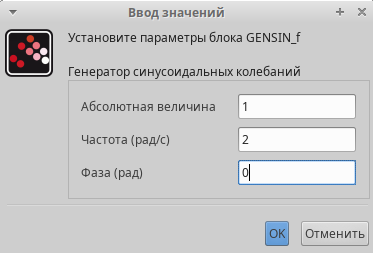

Ввод параметров

## Введем параметры в регистрирующее устройство.

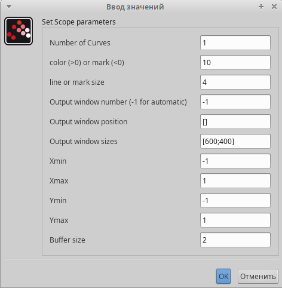

Ввод параметров для CSOPXY

## Выполнив моделирование получим следующий график фигуры Лиссажу при параметрах: *A* = *B* = 1, *a* = 2, *b* = 2, *δ* = 0 (рис. [-@fig:004]). Меняя фазу в первом генераторе на *π*/4; *π*/2; 3*π*/4; *π*; соответственно получим другие фигуры Лиссажу (рис. [-@fig:005]-[-@fig:008]).

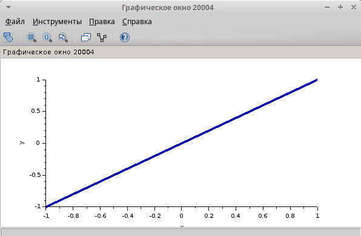

Фигура Лиссажу: *A* = *B* = 1, *a* = 2, *b* = 2, *δ* = 0

## Фигура Лиссажу: *A* = *B* = 1, *a* = 2, *b* = 2, *δ* = *π*/4

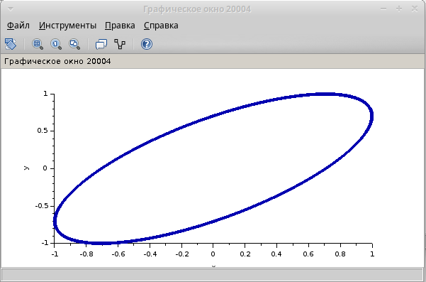

Фигура Лиссажу: *A* = *B* = 1, *a* = 2, *b* = 2, *δ* = *π*/4

## Фигура Лиссажу: *A* = *B* = 1, *a* = 2, *b* = 2, *δ* = *π*/2

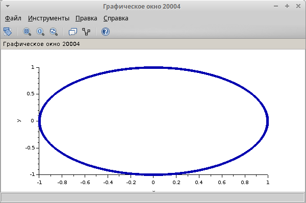

Фигура Лиссажу: *A* = *B* = 1, *a* = 2, *b* = 2, *δ* = *π*/2

## Фигура Лиссажу: *A* = *B* = 1, *a* = 2, *b* = 2, *δ* = 3*π*/4

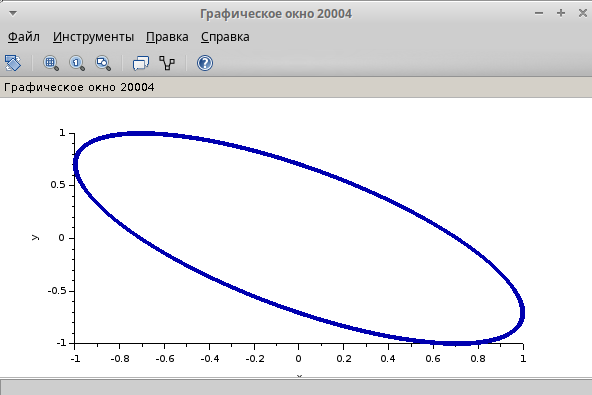

Фигура Лиссажу: *A* = *B* = 1, *a* = 2, *b* = 2, *δ* = 3*π*/4

## Фигура Лиссажу: *A* = *B* = 1, *a* = 2, *b* = 2, *δ* = *π*

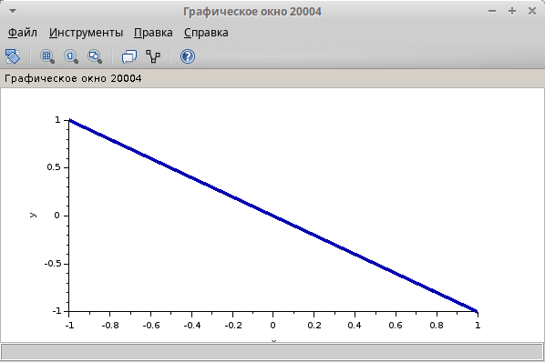

Фигура Лиссажу: *A* = *B* = 1, *a* = 2, *b* = 2, *δ* = *π*

## Изменим параметр частоты на втором генераторе (рис. [-@fig:009]).

[figure not shown]

Ввод параметров для генератора синусоидальных колебаний

## Выполнив моделирование получим следующий график фигуры Лиссажу при параметрах: *A* = *B* = 1, *a* = 2, *b* = 4, *δ* = 0 (рис. [-@fig:010]). Меняя фазу в первом генераторе на *π*/4; *π*/2; 3*π*/4; *π*; соответственно получим другие фигуры Лиссажу (рис. [-@fig:011]-[-@fig:014]).

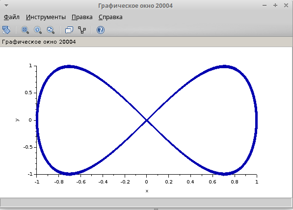

Фигура Лиссажу: *A* = *B* = 1, *a* = 2, *b* = 4, *δ* = 0

## Фигура Лиссажу: *A* = *B* = 1, *a* = 2, *b* = 4, *δ* = *π*/4

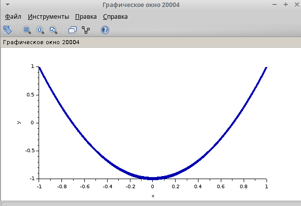

Фигура Лиссажу: *A* = *B* = 1, *a* = 2, *b* = 4, *δ* = *π*/4

## Фигура Лиссажу: *A* = *B* = 1, *a* = 2, *b* = 4, *δ* = *π*/2

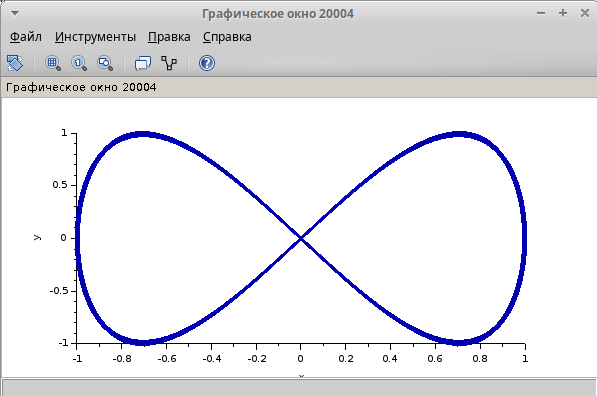

Фигура Лиссажу: *A* = *B* = 1, *a* = 2, *b* = 4, *δ* = *π*/2

## Фигура Лиссажу: *A* = *B* = 1, *a* = 2, *b* = 4, *δ* = 3*π*/4

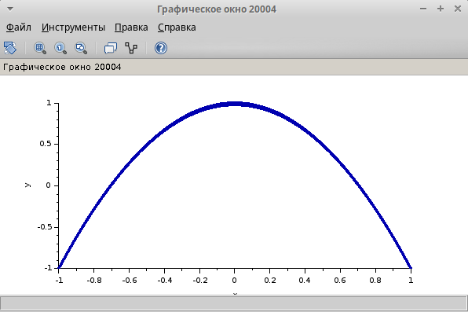

Фигура Лиссажу: *A* = *B* = 1, *a* = 2, *b* = 4, *δ* = 3*π*/4

## Фигура Лиссажу: *A* = *B* = 1, *a* = 2, *b* = 4, *δ* = *π*

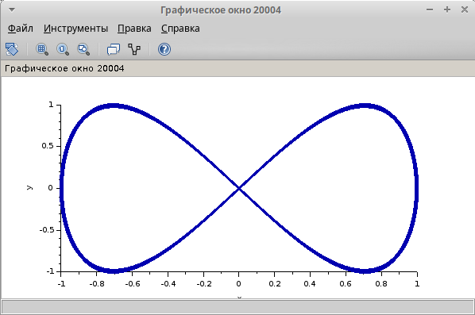

Фигура Лиссажу: *A* = *B* = 1, *a* = 2, *b* = 4, *δ* = *π*

## Изменим параметр частоты на втором генераторе (рис. [-@fig:015]).

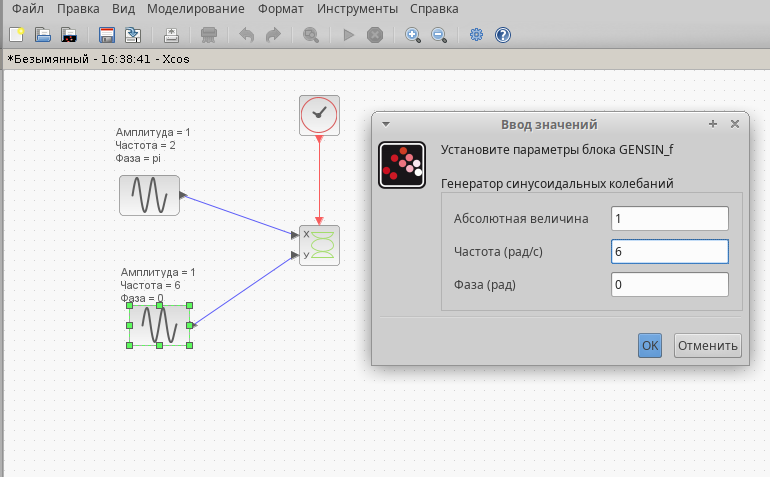

Ввод параметров для генератора синусоидальных колебаний

## Выполнив моделирование получим следующий график фигуры Лиссажу при параметрах: *A* = *B* = 1, *a* = 2, *b* = 6, *δ* = 0 (рис. [-@fig:016]). Меняя фазу в первом генераторе на *π*/4; *π*/2; 3*π*/4; *π*; соответственно получим другие фигуры Лиссажу (рис. [-@fig:017]-[-@fig:020]).

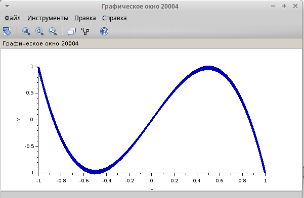

Фигура Лиссажу: *A* = *B* = 1, *a* = 2, *b* = 6, *δ* = 0

## Фигура Лиссажу: *A* = *B* = 1, *a* = 2, *b* = 6, *δ* = *π*/4

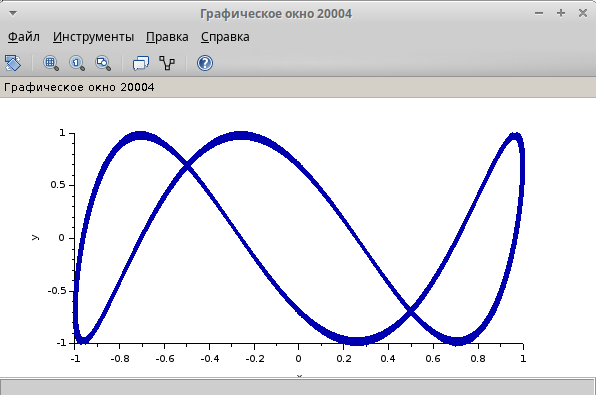

Фигура Лиссажу: *A* = *B* = 1, *a* = 2, *b* = 6, *δ* = *π*/4

## Фигура Лиссажу: *A* = *B* = 1, *a* = 2, *b* = 6, *δ* = *π*/2

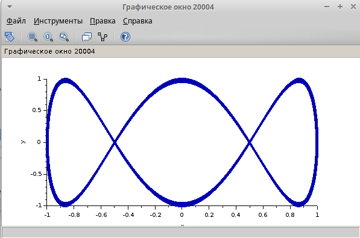

Фигура Лиссажу: *A* = *B* = 1, *a* = 2, *b* = 6, *δ* = *π*/2

## Фигура Лиссажу: *A* = *B* = 1, *a* = 2, *b* = 6, *δ* = 3*π*/4

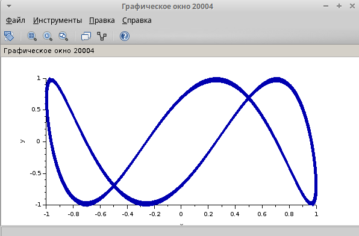

Фигура Лиссажу: *A* = *B* = 1, *a* = 2, *b* = 6, *δ* = 3*π*/4

## Фигура Лиссажу: *A* = *B* = 1, *a* = 2, *b* = 6, *δ* = *π*

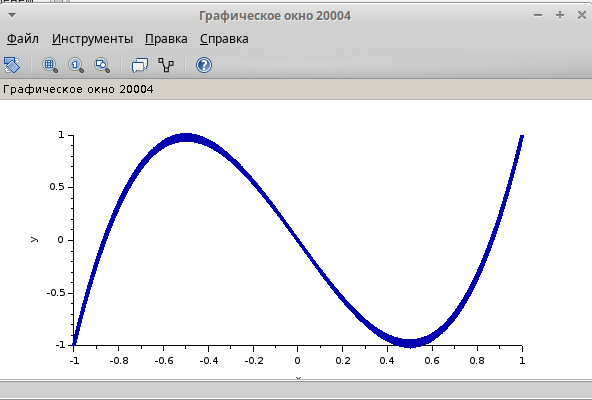

Фигура Лиссажу: *A* = *B* = 1, *a* = 2, *b* = 6, *δ* = *π*

## Изменим параметр частоты на втором генераторе (рис. [-@fig:021]).

[figure not shown]

Ввод параметров для генератора синусоидальных колебаний

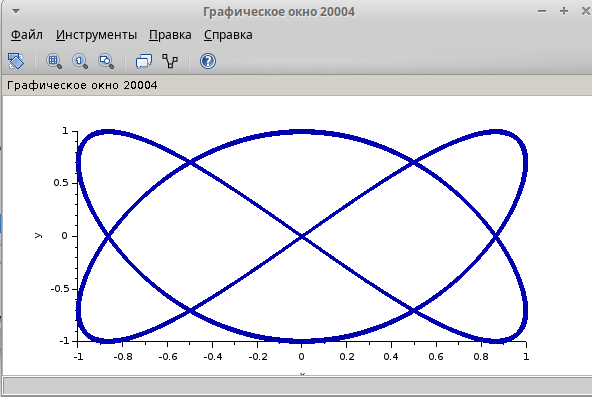

Фигура Лиссажу: *A* = *B* = 1, *a* = 2, *b* = 3, *δ* = 0

## Фигура Лиссажу: *A* = *B* = 1, *a* = 2, *b* = 3, *δ* = *π*/4

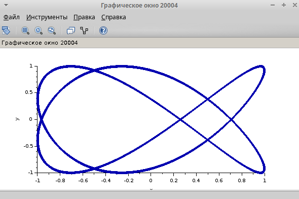

Фигура Лиссажу: *A* = *B* = 1, *a* = 2, *b* = 3, *δ* = *π*/4

## Фигура Лиссажу: *A* = *B* = 1, *a* = 2, *b* = 3, *δ* = *π*/2

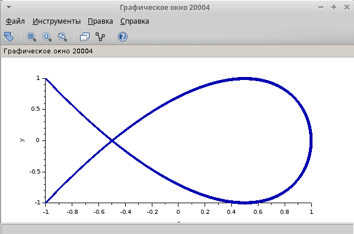

Фигура Лиссажу: *A* = *B* = 1, *a* = 2, *b* = 3, *δ* = *π*/2

## Фигура Лиссажу: *A* = *B* = 1, *a* = 2, *b* = 3, *δ* = 3*π*/4

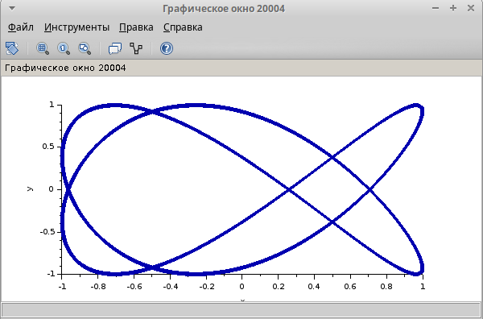

Фигура Лиссажу: *A* = *B* = 1, *a* = 2, *b* = 3, *δ* = 3*π*/4

## Фигура Лиссажу: *A* = *B* = 1, *a* = 2, *b* = 3, *δ* = *π*

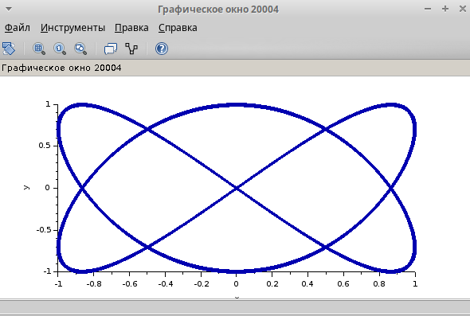

Фигура Лиссажу: *A* = *B* = 1, *a* = 2, *b* = 3, *δ* = *π*

## Выводы

Я выполнил упражнение по ознакомлению с программой *xcos*.

## Список литературы

Королькова А. В., Кулябов Д.С. “Материалы к лабораторным работам”